# Machine_learning

emil_d

4 lipca 2017

## Background

Using devices such as Jawbone Up, Nike FuelBand, and Fitbit it is now possible to collect a large amount of data about personal activity relatively inexpensively. These type of devices are part of the quantified self movement – a group of enthusiasts who take measurements about themselves regularly to improve their health, to find patterns in their behavior, or because they are tech geeks. One thing that people regularly do is quantify how much of a particular activity they do, but they rarely quantify how well they do it. In this project, your goal will be to use data from accelerometers on the belt, forearm, arm, and dumbell of 6 participants. They were asked to perform barbell lifts correctly and incorrectly in 5 different ways. More information is available from the website here: http://groupware.les.inf.puc-rio.br/har (see the section on the Weight Lifting Exercise Dataset).

### Data

The training data for this project are available here:

https://d396qusza40orc.cloudfront.net/predmachlearn/pml-training.csv

The test data are available here:

https://d396qusza40orc.cloudfront.net/predmachlearn/pml-testing.csv

The data for this project come from this source: http://groupware.les.inf.puc-rio.br/har. If you use the document you create for this class for any purpose please cite them as they have been very generous in allowing their data to be used for this kind of assignment.

## Prediction exercise

```r
#load libraries
library(caret)
library(randomForest)
```

```r
library(rpart)
library(rpart.plot)
set.seed(1205)
```

### Load data

```r
#loading trainingset
train <- read.csv(url("https://d396qusza40orc.cloudfront.net/predmachlearn/pml-training.csv"), na.strings = c("NA", "", "#DIV0!"))
#loading testingset
test <- read.csv(url("https://d396qusza40orc.cloudfront.net/predmachlearn/pml-testing.csv"), na.strings = c("NA", "", "#DIV0!"))
```

### Cleaning and preparing data

```r
# check training and test data integrity
colnames(train)[colnames(train) != colnames(test)]
```

```
## [1] "classe"
```

There is a difference in columns.

```r
# Delete columns with missing data
train<-train[,colSums(is.na(train)) == 0]
test<-test[,colSums(is.na(test)) == 0]

#Delete unnecessary columns
train <-train[,-c(1:7)]
test <-test[,-c(1:7)]
```

Data is cleaned - columns with irrevelant data and with missed values were deleted.

### Model

Main variable is classe. This variable should be outcome variable. Firstly crossvalidation will be performed.

```r
#data splitting into two partitions without replacement
partition <- createDataPartition(y=train$classe, p=0.80, list=FALSE)
parTrain <- train[partition,]
parTest <- train[-partition,]
```

Lets look into data

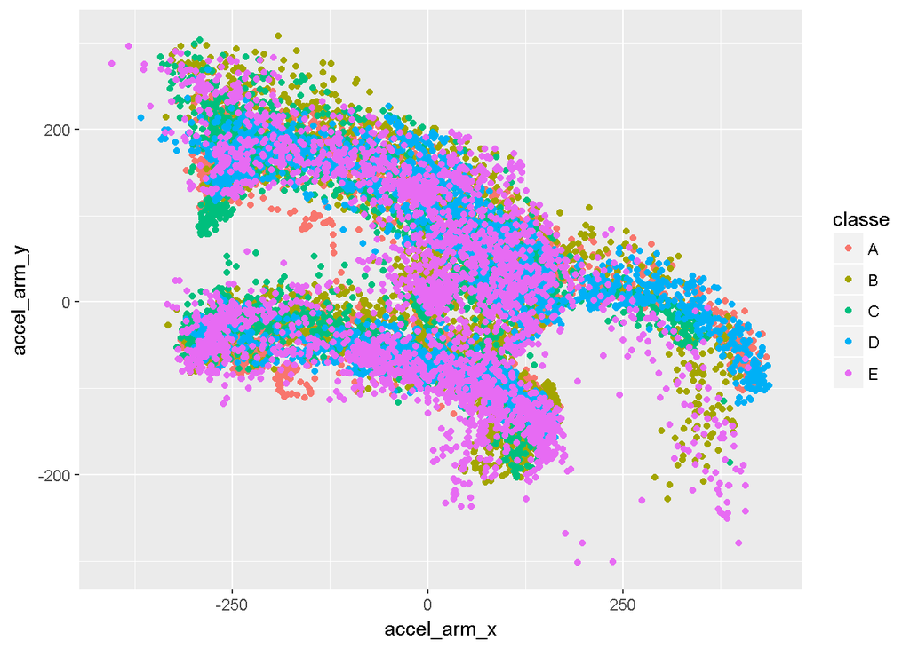

```r
#plot training data
qplot(accel_arm_x, accel_arm_y, col=classe, data=parTrain)
```

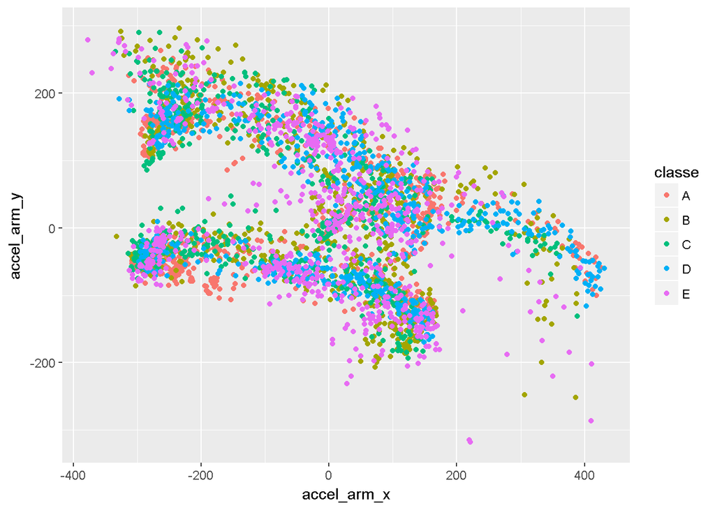

```r
#plot test data
qplot(accel_arm_x, accel_arm_y, col=classe, data=parTest)
```

#### Classification tree

```r
classTree <- rpart(classe ~ ., data=parTrain, method="class")
preTree <- predict(classTree, parTest, type="class")
confusionMatrix(preTree, parTest$classe)
```

```
## Confusion Matrix and Statistics
##
##           Reference
## Prediction    A    B    C    D    E
##          A 1016  103   10   38   12
##          B   43  489   53   58   64
##          C   25   71  561   99   90
##          D   15   58   39  404   43
##          E   17   38   21   44  512
##
## Overall Statistics
##
##                Accuracy : 0.7601
##                  95% CI : (0.7465, 0.7734)
##     No Information Rate : 0.2845
##     P-Value [Acc > NIR] : < 2.2e-16
##
##                   Kappa : 0.696
##  Mcnemar's Test P-Value : < 2.2e-16
##
## Statistics by Class:
##
##                      Class: A Class: B Class: C Class: D Class: E
## Sensitivity            0.9104   0.6443   0.8202   0.6283   0.7101
## Specificity            0.9419   0.9311   0.9120   0.9527   0.9625
## Pos Pred Value         0.8617   0.6917   0.6631   0.7227   0.8101
## Neg Pred Value         0.9636   0.9160   0.9600   0.9290   0.9365
## Prevalence             0.2845   0.1935   0.1744   0.1639   0.1838
## Detection Rate         0.2590   0.1246   0.1430   0.1030   0.1305
## Detection Prevalence   0.3005   0.1802   0.2157   0.1425   0.1611
## Balanced Accuracy      0.9262   0.7877   0.8661   0.7905   0.8363
```

There is a plot of tree

[figure not shown]

```r
rpart.plot(classTree)
```

#### Random forest

```r
classRF <- randomForest(classe ~ ., data=parTrain, method="class")
preRF <- predict(classRF, parTest, type="class")
confusionMatrix(preRF, parTest$classe)
```

```
## Confusion Matrix and Statistics
##
##           Reference
## Prediction    A    B    C    D    E
##          A 1115    2    0    0    0
##          B    1  755    5    0    0
##          C    0    2  679    9    0
##          D    0    0    0  634    1
##          E    0    0    0    0  720
##
## Overall Statistics
##
##                Accuracy : 0.9949
##                  95% CI : (0.9921, 0.9969)
##     No Information Rate : 0.2845
##     P-Value [Acc > NIR] : < 2.2e-16
##
##                   Kappa : 0.9936
##  Mcnemar's Test P-Value : NA
##
## Statistics by Class:
##
##                      Class: A Class: B Class: C Class: D Class: E
## Sensitivity            0.9991   0.9947   0.9927   0.9860   0.9986
## Specificity            0.9993   0.9981   0.9966   0.9997   1.0000
## Pos Pred Value         0.9982   0.9921   0.9841   0.9984   1.0000
## Neg Pred Value         0.9996   0.9987   0.9985   0.9973   0.9997
## Prevalence             0.2845   0.1935   0.1744   0.1639   0.1838
## Detection Rate         0.2842   0.1925   0.1731   0.1616   0.1835
## Detection Prevalence   0.2847   0.1940   0.1759   0.1619   0.1835
## Balanced Accuracy      0.9992   0.9964   0.9946   0.9928   0.9993
```

Here is a visualisation of bad predictions

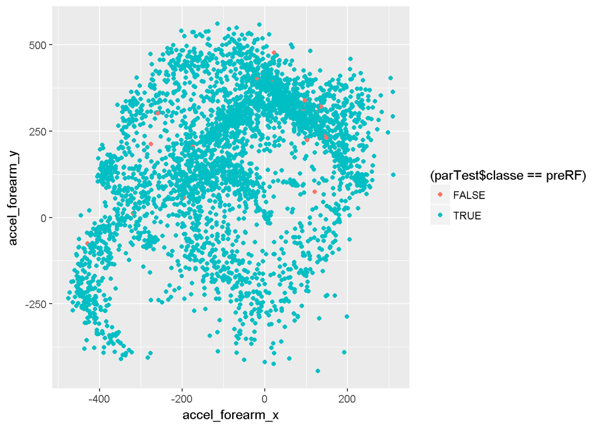

```r
qplot(accel_forearm_x, accel_forearm_y, col=(parTest$classe == preRF), data = parTest)
```

### Summary

In this case Random forest has better accurancy: Classification tree = 0.7601  
Random forest = 0.9949